# DVF Script 4

[Boris Mericskay](https://perso.univ-rennes2.fr/boris.mericskay) et [Florent Demoraes](https://perso.univ-rennes2.fr/florent.demoraes)

02/07/2021 - Mise à jour 08/10/2026

# 1 LES DONNÉES DVF À UNE ÉCHELLE LOCALE : LES EXEMPLES DE LA MÉTROPOLE RÉGIONALE ET DE LA COMMUNE DE RENNES

Ce script décrit plusieurs fonctions de manipulation de la dimension spatiale des données DVF. Il propose aussi plusieurs formes de représentation cartographique de ces données à une échelle métropolitaine (Rennes Métropole).

## 1.1 Chargement des packages nécessaires

```r
library(tidyverse) # Manipulation de données
library(sf) # Manipulation de données spatiales
library(mapsf) # Cartographie thématique
library(spdep) # pour calculer l'auto-corrélation spatiale
library(spatstat) # pour produire des surfaces lissées
library(terra) # pour le traitement de données matricielles (raster)
library(cluster) # pour la CAH
library(data.table) # pour manipuler des tables volumineuses et réaliser des agrégations avec une performance accrue
library(sfarrow) # pour lire et écrire des fichiers geoparquets
```

## 1.2 Import du jeu de données brut

```r
DVF <- fread("Resultats/DVFOK.csv", encoding = "UTF-8")
MutationsBZH <- st_read_parquet("Resultats/Mutations_Bzh.parquet")
```

## 1.3 Créer le jeu de données correspondant à Rennes métropole (RM)

### 1.3.1 Extraire les mutations de Rennes Métropole

```r
MutationsRM <- MutationsBZH %>% filter(EPCI == 'Rennes Métropole')
```

### 1.3.2 Création d’un tableau avec les indicateurs immobiliers de RM

```r
RecapRM <- MutationsRM %>%
  st_drop_geometry() %>%
  group_by(type) %>%
  dplyr::summarise(
    tot       = n(),
    prixmed   = round(median(prix)),
    prixmoy   = round(mean(prix)),
    surfmed   = round(median(surface)),
    surfmoy   = round(mean(surface)),
    prixm2med = round(median(prixm2)),
    prixm2moy = round(mean(prixm2))
  ) %>%
  mutate(part = round(tot / sum(tot) * 100, 1))

print(RecapRM)
```

```
## # A tibble: 2 × 9
##   type          tot prixmed prixmoy surfmed surfmoy prixm2med prixm2moy  part
##   <chr>       <int>   <dbl>   <dbl>   <dbl>   <dbl>     <dbl>     <dbl> <dbl>
## 1 Appartement 20555  127800  141862      62      60      2346      2470  64.8
## 2 Maison      11167  250000  277522     104     111      2361      2570  35.2
```

## 1.4 Exploration des prix et des volumes en prenent l’échelon des Iris comme niveau d’analyse

### 1.4.1 Importer la couche des Iris (IGN)

```r
IRISRM <- st_read("Donnees/IRISRM.shp")
```

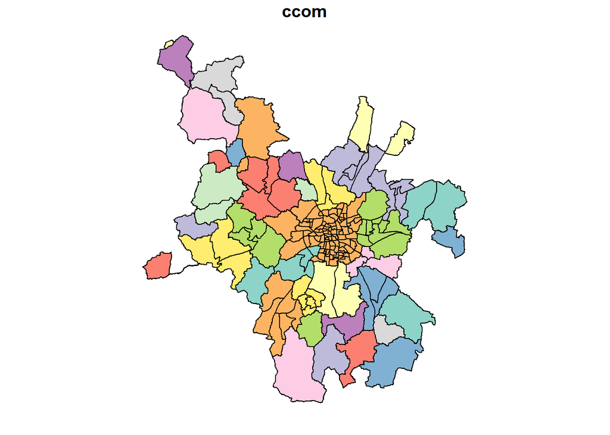

```r
plot(IRISRM["ccom"])
```

### 1.4.2 Calculer et cartographier le prix moyen au m² par Iris

```r
# Réimporter si nécessaire la couche des communes de Bretagne enrichie dans le script 3
Communes <- st_read("Resultats/CommunesBZHDVF.gpkg")
```

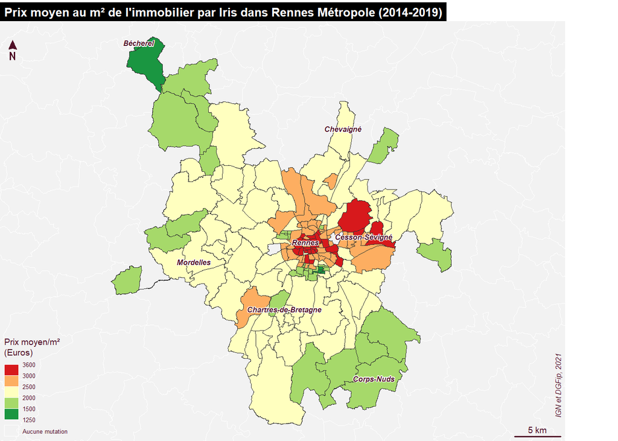

```r
# Calcul du prix moyen au m² par IRIS
IRISDVF <- IRISRM %>%
  st_join(MutationsRM) %>%
  group_by(code_iris) %>%
  summarise(Prixm2 = round(mean(prixm2)))

# Sélection des communes dont le nom sera affiché sur la carte
liste_noms_RM <- c("Rennes", "Cesson-Sévigné", "Chartres-de-Bretagne", "Bécherel", "Mordelles", "Corps-Nuds", "Chevaigné")
Selection_Communes_RM <- Communes[which(Communes$NOM_COM %in% liste_noms_RM),]

# Paramétrage des marges de la fenêtre pour maximiser l'emprise de la carte
op <- par(mar = c(0, 0, 1.2, 3))

# Affichage des communes de RM et alentours en arrière-plan et centrage de la carte sur Rennes Métropole
plot(st_geometry(Communes), lwd = 0.1, col = "grey95", border = "white", bg = "#B5D0D0", xlim = c(st_bbox(IRISRM)[1], st_bbox(IRISRM)[3]), ylim = c(st_bbox(IRISRM)[2], st_bbox(IRISRM)[4]))

mf_map(
  x = IRISDVF,
  var = "Prixm2",
  type = "choro",
  breaks = c(1250, 1500, 2000, 2500, 3000, 3600),
  pal = c("#1a9641", "#a6d96a", "#ffffbf", "#fdae61", "#d7191c"),
  lwd = 0.001,
  border = "grey20",
  leg_title = "Prix moyen/m² \n(Euros)",
  leg_pos = "bottomleft",
  leg_box_border = "white",
  leg_no_data = "Aucune mutation",
  col_na = NA,
  leg_val_rnd = 0,
  leg_title_cex = 0.6,
  leg_val_cex = 0.4,
  leg_size = 0.7,
  add = TRUE
)

# Ajouter les étiquettes des communes selectionnées plus haut
mf_label(Selection_Communes_RM, var = "NOM_COM", halo = TRUE, bg = "white", r = 0.05, cex = 0.5, pos = 3, font = 4, offset = 0)

# Habillage de la carte
mf_title("Prix moyen au m² de l'immobilier par Iris dans Rennes Métropole (2014-2019)", cex = 0.8, tab = TRUE, fg = "white", bg = "black", line = 1, pos = "left")

mf_arrow(adj = c(1,-3))
mf_scale()

mf_credits(txt = "          IGN et DGFip, 2021", cex = 0.5, pos = 'rightbottom')
```

```r
par(op)
```

### 1.4.3 Calculer et cartographier le nombre de mutations par Iris

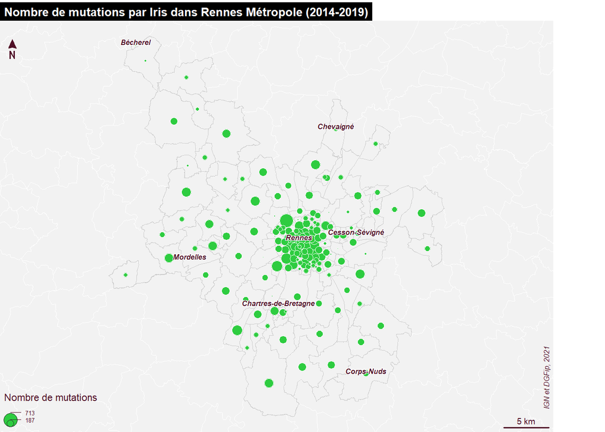

```r
# Calcul du nombre de mutations par IRIS
IRISDVF <- IRISDVF %>%
  mutate(Nbmutations = lengths(st_intersects(IRISDVF, MutationsRM)))
IRISDVF <- IRISDVF %>% na.omit() # pour supprimer les valeurs manquantes

# Paramétrage des marges de la fenêtre pour maximiser l'emprise de la carte
op <- par(mar = c(0, 0, 1.2, 3))

# Affichage des communes de RM et alentours en arrière-plan et centrage de la carte sur Rennes Métropole
plot(st_geometry(Communes), lwd = 0.1, col = "grey95", border = "white", bg = "#B5D0D0", xlim = c(st_bbox(IRISRM)[1], st_bbox(IRISRM)[3]), ylim = c(st_bbox(IRISRM)[2], st_bbox(IRISRM)[4]))

# Affichage des IRIS
plot(st_geometry(IRISRM), # appel du jeu de données
     border = "grey80", # couleur de la bordure des IRIS
     add = TRUE,
     lwd = 0.05)

# Affichage des symboles proportionnels (nombre de mutations)
mf_map(x = IRISDVF,
          type = "prop",
          var = "Nbmutations", # variable à cartographier
          col = "#2ECC40", # couleur des cercles
          border = "white",  # couleur du contour des cercles
          inches = 0.08, # taille du cercle max
          lwd = 0.01, # épaisseur du contour des cercles
          leg_pos = NA,
          add = TRUE)

mf_legend(type = 'prop',
          val = c(median(IRISDVF$Nbmutations), max(IRISDVF$Nbmutations)),
          pos = "bottomleft",
          title = "Nombre de mutations",
          title_cex = 0.7,
          lwd = 0.01,
          val_cex = 0.4,
          inches = 0.08,
          col = "#2ECC40",
          frame = FALSE,
          val_rnd = 0
)

# Ajouter les étiquettes des communes selectionnées plus haut
mf_label(Selection_Communes_RM, var = "NOM_COM", halo = TRUE, bg = "white", r = 0.05, cex = 0.5, pos = 3, font = 4, offset = 0)

# Habillage de la carte
mf_title("Nombre de mutations par Iris dans Rennes Métropole (2014-2019)", cex = 0.8, tab = TRUE, fg = "white", bg = "black", line = 1, pos = "left")

mf_arrow(adj = c(1,-3))
mf_scale()

mf_credits(txt = "          IGN et DGFip, 2021", cex = 0.5, pos = 'rightbottom')
```

```r
par(op)
```

## 1.5 Exploration des prix et des volumes en prenant les sections cadastrales comme échelon d’analyse

### 1.5.1 Importer la couche des sections cadastrales (DGFip)

```r
Sections <- st_read("Donnees/Sectionscadastrales.shp")
```

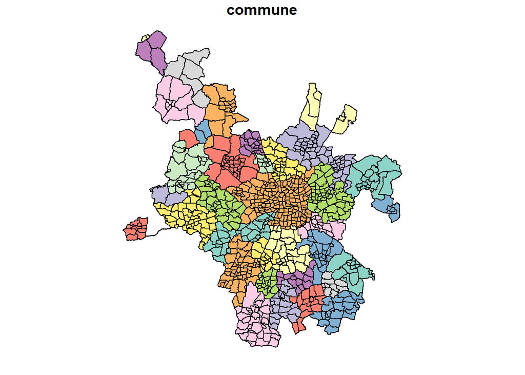

```r
Sections <- Sections %>% mutate(codesection = id)
plot(Sections["commune"])
```

### 1.5.2 Calculer et cartographier le prix moyen au m² par section cadastrale

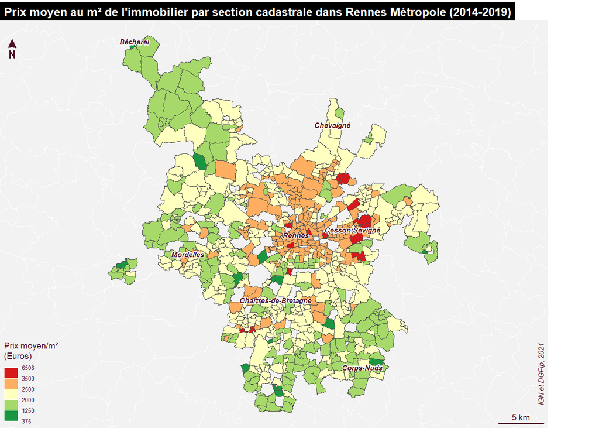

```r
# Calcul du prix moyen au m² par section
SectionsDVF <- Sections %>%
  st_join(MutationsRM) %>%
  group_by(codesection) %>%
  summarise(Prixm2 = round(mean(prixm2)))
SectionsDVF <- SectionsDVF %>% na.omit() # pour supprimer les valeurs manquantes

# Paramétrage des marges de la fenêtre pour maximiser l'emprise de la carte
op <- par(mar = c(0, 0, 1.2, 3))

# Affichage des communes de RM et alentours en arrière-plan et centrage de la carte sur Rennes Métropole
plot(st_geometry(Communes), lwd = 0.1, col = "grey95", border = "white", bg = "#B5D0D0", xlim = c(st_bbox(IRISRM)[1], st_bbox(IRISRM)[3]), ylim = c(st_bbox(IRISRM)[2], st_bbox(IRISRM)[4]))

# Affichage de la carte des prix au m² par section cadastrale
mf_map(
  x = SectionsDVF,
  var = "Prixm2",
  type = "choro",
  breaks = c(min(SectionsDVF$Prixm2), 1250, 2000, 2500, 3500, max(SectionsDVF$Prixm2)),
  pal = c("#1a9641", "#a6d96a", "#ffffbf", "#fdae61", "#d7191c"),
  lwd = 0.001,
  border = "grey30",
  leg_title = "Prix moyen/m² \n(Euros)",
  leg_pos = "bottomleft",
  leg_box_border = "white",
  leg_no_data = "Aucune mutation",
  col_na = NA,
  leg_val_rnd = 0,
  leg_title_cex = 0.6,
  leg_val_cex = 0.4,
  leg_size = 0.7,
  add = TRUE
)

# Ajouter les étiquettes des communes selectionnées plus haut
mf_label(Selection_Communes_RM, var = "NOM_COM", halo = TRUE, bg = "white", r = 0.05, cex = 0.5, pos = 3, font = 4, offset = 0)

# Habillage de la carte
mf_title("Prix moyen au m² de l'immobilier par section cadastrale dans Rennes Métropole (2014-2019)", cex = 0.8, tab = TRUE, fg = "white", bg = "black", line = 1, pos = "left")

mf_arrow(adj = c(1,-3))
mf_scale()

mf_credits(txt = "          IGN et DGFip, 2021", cex = 0.5, pos = 'rightbottom')
```

```r
par(op)
```

### 1.5.3 Calculer et cartographier le nombre de mutations par section cadastrale

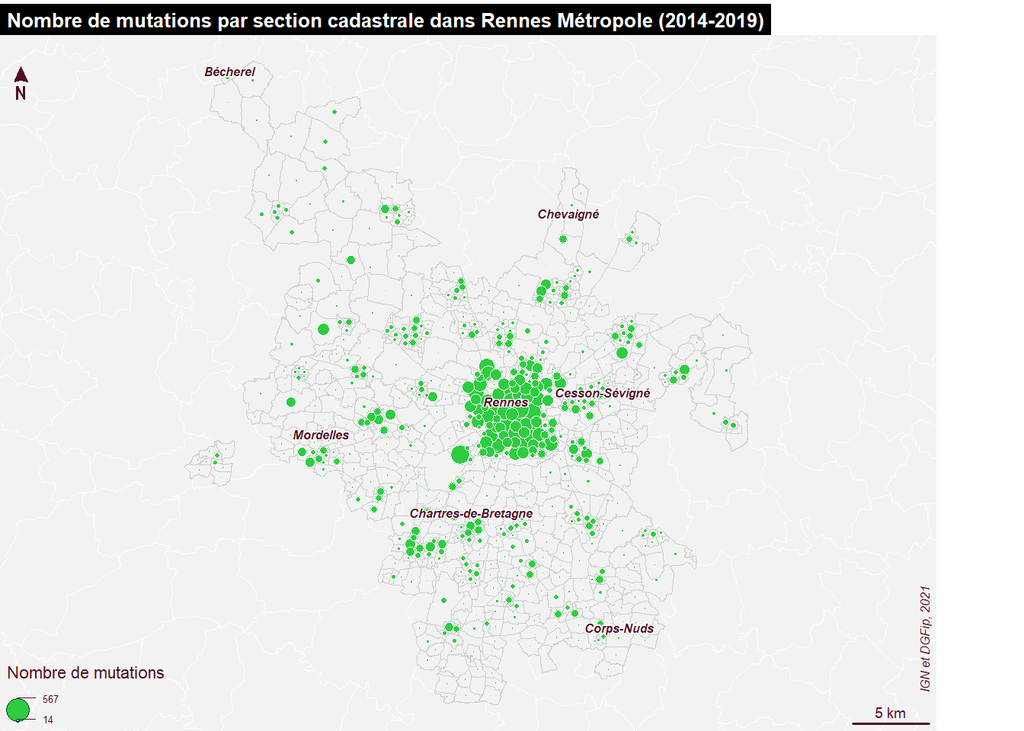

```r
# Calcul du nombre de mutations par section
SectionsDVF <- SectionsDVF %>%
  mutate(Nbmutations = lengths(st_intersects(SectionsDVF, MutationsRM)))

# Paramétrage des marges de la fenêtre pour maximiser l'emprise de la carte
op <- par(mar = c(0, 0, 1.2, 3))

# Affichage des communes de RM et alentours en arrière-plan et centrage de la carte sur Rennes Métropole
plot(st_geometry(Communes), lwd = 0.1, col = "grey95", border = "white", bg = "#B5D0D0", xlim = c(st_bbox(IRISRM)[1], st_bbox(IRISRM)[3]), ylim = c(st_bbox(IRISRM)[2], st_bbox(IRISRM)[4]))

# Affichage des sections cadastrales
plot(st_geometry(SectionsDVF), # appel du jeu de données
     border = "grey80", # couleur de la bordure
     add = TRUE,
     lwd = 0.05)

# Affichage des symboles proportionnels (nombre de mutations)

mf_map(x = SectionsDVF,
          type = "prop",
          var = "Nbmutations", # variable à cartographier
          col = "#2ECC40", # couleur des cercles
          border = "white",  # couleur du contour des cercles
          inches = 0.08, # taille du cercle max
          lwd = 0.01, # épaisseur du contour des cercles
          leg_title = "Ventes d'appartements \npar commune",
          leg_pos = NA,
          add = TRUE)

mf_legend(type = 'prop',
          val = c(median(SectionsDVF$Nbmutations), max(SectionsDVF$Nbmutations)),
          pos = "bottomleft",
          title = "Nombre de mutations",
          title_cex = 0.7,
          lwd = 0.01,
          val_cex = 0.4,
          inches = 0.08,
          col = "#2ECC40",
          frame = FALSE,
          val_rnd = 0
)

# Ajouter les étiquettes des communes selectionnées plus haut
mf_label(Selection_Communes_RM, var = "NOM_COM", halo = TRUE, bg = "white", r = 0.05, cex = 0.5, pos = 3, font = 4, offset = 0)

# Habillage de la carte
mf_title("Nombre de mutations par section cadastrale dans Rennes Métropole (2014-2019)", cex = 0.8, tab = TRUE, fg = "white", bg = "black", line = 1, pos = "left")

mf_arrow(adj = c(1,-3))
mf_scale()

mf_credits(txt = "          IGN et DGFip, 2021", cex = 0.5, pos = 'rightbottom')
```

```r
par(op)
```

## 1.6 Lissage spatial (échelle métropolitaine)

### 1.6.1 Lissage spatial des prix de l’immobilier au m² calculés à partir des valeurs agrégées par Iris

#### 1.6.1.1 Calcul des distances au plus proche voisin et de l’auto-corrélation spatiale des prix au m²

```r
# pour calculer les pseudo-centroides des Iris (indispensable pour le calcul sur les plus proches voisins)
IRISDVF.Centroids <- st_point_on_surface(IRISDVF)

# Identification du plus proche voisin de chaque Iris
listPPV <- knearneigh(IRISDVF.Centroids, k = 1)

# pour convertir l'objet knn en objet nb
PPV <- knn2nb(listPPV, row.names = IRISDVF.Centroids$code_iris)

# pour connaître la distance entre plus proches voisins
distPPV <- nbdists(PPV, IRISDVF.Centroids)

summary(unlist(distPPV))
```

```
##    Min. 1st Qu.  Median    Mean 3rd Qu.    Max.
##   150.7   439.7   756.3  1262.3  1977.3  5390.4
```

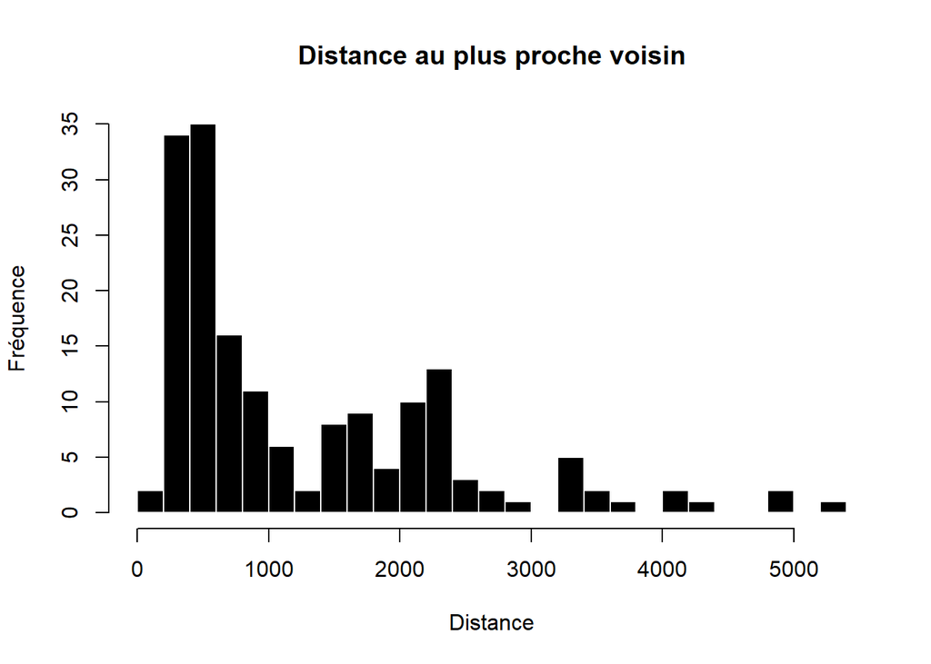

```r
hist(unlist(distPPV), breaks = 20,
     main = "Distance au plus proche voisin",
     col = "black", border = "white", xlab = "Distance", ylab = "Fréquence")
```

```r
# pour convertir les Iris en objet nb
IRIS.nb <- poly2nb(pl = IRISDVF,
                 snap = 50,
                 queen = TRUE)

#calcul du test de Moran
moran.test(IRISDVF$Prixm2, listw = nb2listw(IRIS.nb))
```

```
##
##  Moran I test under randomisation
##
## data:  IRISDVF$Prixm2
## weights: nb2listw(IRIS.nb)
##
## Moran I statistic standard deviate = 14.586, p-value < 2.2e-16
## alternative hypothesis: greater
## sample estimates:
## Moran I statistic       Expectation          Variance
##       0.686719815      -0.005917160       0.002254835
```

#### 1.6.1.2 Carte lissée des prix de l’immobilier au m² calculés à partir des valeurs agrégées par Iris sur l’ensemble de Rennes Métropole

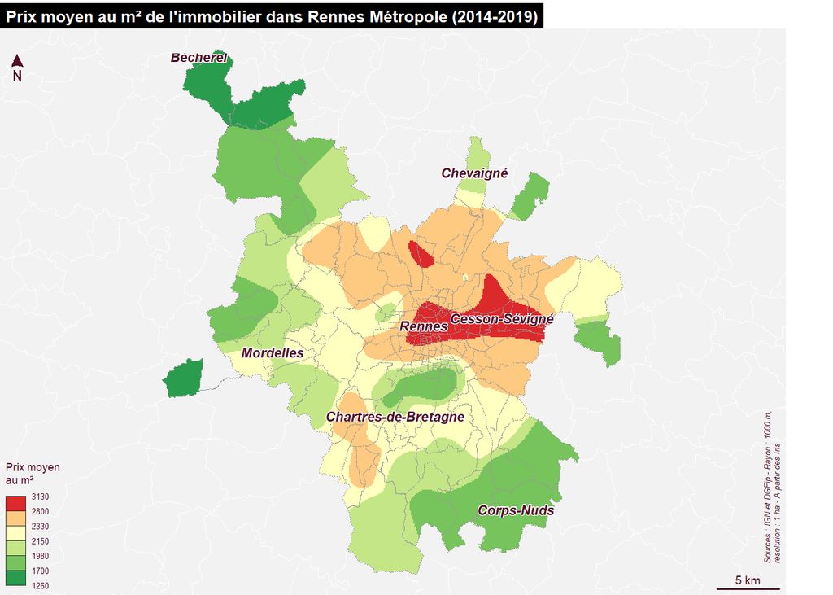

```r
# lissage avec spatstat car peu d'unités spatiales ici

# pour définir le contour de Rennes Métropole comme emprise pour le lissage (sinon le lissage est calculé sur une fenêtre rectangulaire)
EmpriseRM <- as.owin(IRISRM) # objet spatstat

# pour récupérer les coordonnées du centroïde des IRIS
pts <- st_coordinates(st_point_on_surface(IRISDVF))

# pour créer un objet ppp (format spatstat) et y intégrer dedans l'emprise et les valeurs à lisser (prix au m²)
IRISDVF.ppp <- ppp(pts[,1],
                   pts[,2],
                   window = EmpriseRM,
                   marks = IRISDVF$Prixm2)

# pour calculer la surface lissée (rayon lissage : 1 km et resolution spatiale de l'image : 1 ha)
cartelissee <- Smooth(IRISDVF.ppp, sigma = 1000, eps = 100)

# Conversion de la surface lissée au format raster
cartelissee.raster <- rast(cartelissee)
crs(cartelissee.raster) <- st_crs(Communes)$srid

# Paramétrage des marges de la fenêtre pour maximiser l'emprise de la carte
op <- par(mar = c(0, 0, 1.2, 2))

# pour afficher la surface lissée et définir l'habillage
# Calcul des seuils
bks <- unique(mf_get_breaks(values(cartelissee.raster), breaks = "q6"))

# Création d'une palette de couleurs (double gradation harmonique)
cols <- c("#2a9c4e", "#77c35c", "#c4e687", "#ffffc0", "#fec981", "#dc292c")

# Affichage des communes de RM et alentours en arrière-plan et centrage de la carte sur Rennes Métropole
plot(st_geometry(Communes), lwd = 0.1, col = "grey95", border = "white", bg = "#B5D0D0", xlim = c(st_bbox(IRISRM)[1], st_bbox(IRISRM)[3]), ylim = c(st_bbox(IRISRM)[2], st_bbox(IRISRM)[4]))

# Affichage de la carte lissée et du contour des Iris
plot(cartelissee.raster, breaks = bks, col = cols, add = T, legend = F)
plot(IRISDVF$geometry, border = "grey60", lwd = 0.05, lty = 3, add = T)

mf_legend(type = "choro",
          pos = "bottomleft",
          title = "Prix moyen \nau m²",
          val = bks,
          no_data = FALSE,
          val_rnd = -1,
          pal = cols,
          size = 0.7)

# Habillage de la carte
mf_title("Prix moyen au m² de l'immobilier dans Rennes Métropole (2014-2019)", cex = 0.8, tab = TRUE, fg = "white", bg = "black", line = 1, pos = "left")

mf_arrow(adj = c(1,-3))
mf_scale()

mf_credits(txt = "          Sources : IGN et DGFip - Rayon : 1000 m,\n          résolution : 1 ha - A partir des Iris", cex = 0.4, pos = 'rightbottom')

# Ajouter les étiquettes des communes sélectionnées plus haut
mf_label(Selection_Communes_RM, var = "NOM_COM", halo = TRUE, bg = "white", r = 0.05, cex = 0.7, pos = 3, font = 4, offset = 0)
```

```r
par(op)
```

### 1.6.2 Lissage spatial du prix de l’immobilier au m² calculés à partir des valeurs agrégées par section cadastrale

#### 1.6.2.1 Calcul des distances au plus proche voisin et de l’auto-corrélation spatiale des prix au m²

```r
# pour calculer les pseudo-centroides des sections cadastrales (indispensable pour le calcul sur les plus proches voisins)
SectionsDVF.Centroids <- st_point_on_surface(SectionsDVF)

# pour connaître le plus proche voisin de chaque section cadastrale
listPPV <- knearneigh(SectionsDVF.Centroids, k = 1)

# pour convertir l'objet knn en objet nb
PPV <- knn2nb(listPPV, row.names = SectionsDVF.Centroids$codesection)

# pour connaître la distance entre plus proches voisins
distPPV <- nbdists(PPV, SectionsDVF.Centroids)

summary(unlist(distPPV))
```

```
##    Min. 1st Qu.  Median    Mean 3rd Qu.    Max.
##   240.3   443.9   542.6   651.5   798.3  2347.6
```

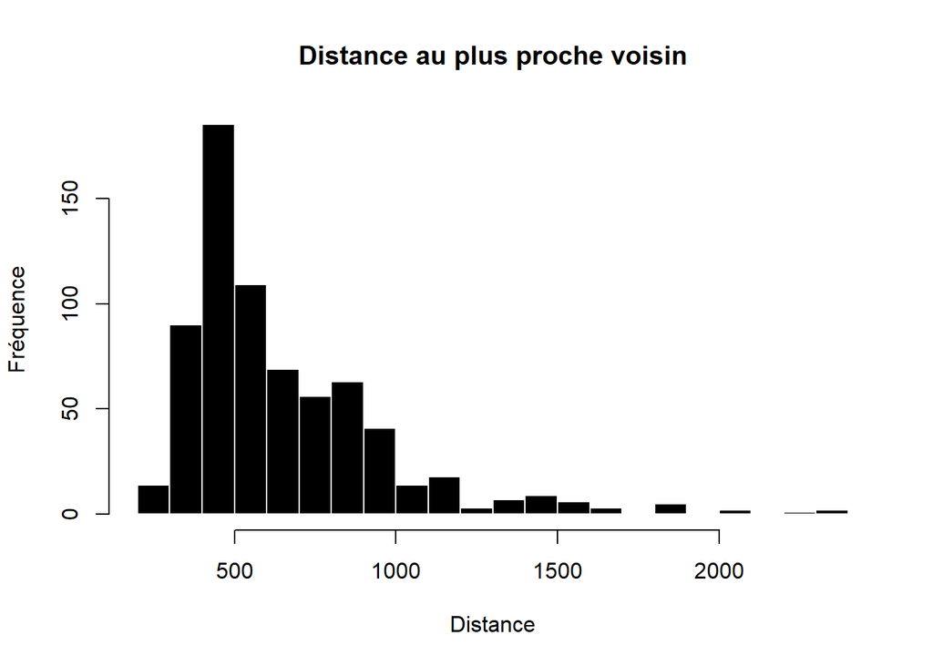

```r
hist(unlist(distPPV), breaks = 20,
     main = "Distance au plus proche voisin",
     col = "black", border = "white", xlab = "Distance", ylab = "Fréquence")
```

```r
# pour convertir les sections en objet nb
Section.nb <- poly2nb(pl = SectionsDVF,
                 snap = 50,
                 queen = TRUE)

#calcul du test de Moran
moran.test(SectionsDVF$Prixm2, listw = nb2listw(Section.nb))
```

```
##
##  Moran I test under randomisation
##
## data:  SectionsDVF$Prixm2
## weights: nb2listw(Section.nb)
##
## Moran I statistic standard deviate = 19.586, p-value < 2.2e-16
## alternative hypothesis: greater
## sample estimates:
## Moran I statistic       Expectation          Variance
##      0.4729450391     -0.0014367816      0.0005866279
```

#### 1.6.2.2 Carte lissée des prix de l’immobilier au m² calculés à partir des valeurs agrégées par section cadastrale sur l’ensemble de Rennes Métropole

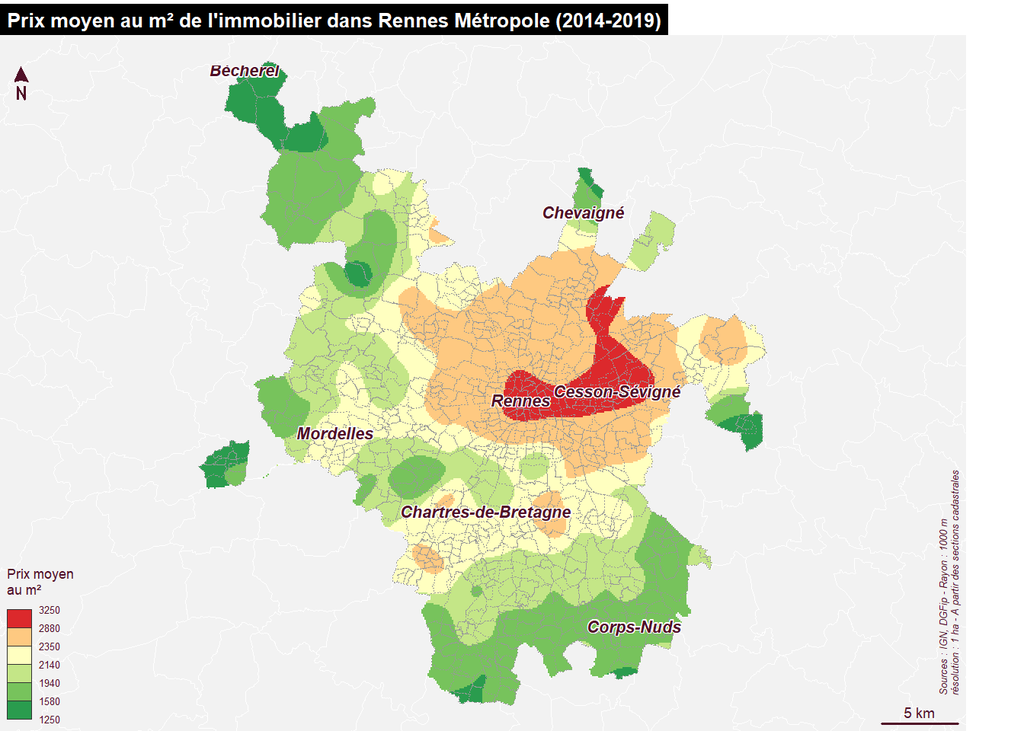

```r
# pour définir le contour de Rennes Métropole comme emprise pour le lissage (sinon le lissage est calculé sur une fenêtre rectangulaire)
EmpriseRM <- as.owin(IRISRM)

# pour récupérer les coordonnées du centroïde des sections
pts <- st_coordinates(st_point_on_surface(SectionsDVF))

# pour créer un objet ppp (format spatstat) et y intégrer dedans l'emprise et les valeurs à lisser (prix au m²)
Sections.ppp <- ppp(pts[,1],
                    pts[,2],
                    window = EmpriseRM,
                    marks = SectionsDVF$Prixm2)

# pour calculer la surface lissée (rayon lissage : 1 km et resolution spatiale de l'image : 1 ha)
cartelissee <- Smooth(Sections.ppp, sigma = 1000, eps = 100)

# Conversion de la surface lissée au format raster
cartelissee.raster <- rast(cartelissee)
crs(cartelissee.raster) <- st_crs(Communes)$srid

# Paramétrage des marges de la fenêtre pour maximiser l'emprise de la carte
op <- par(mar = c(0, 0, 1.2, 2))

# pour afficher la surface lissée et définir l'habillage
# Calcul des seuils
bks <- unique(mf_get_breaks(values(cartelissee.raster), breaks = "q6"))

# Création d'une palette de couleurs (double gradation harmonique)
cols <- c("#2a9c4e", "#77c35c", "#c4e687", "#ffffc0", "#fec981", "#dc292c")

# Affichage des communes de RM et alentours en arrière-plan et centrage de la carte sur Rennes Métropole
plot(st_geometry(Communes), lwd = 0.1, col = "grey95", border = "white", bg = "#B5D0D0", xlim = c(st_bbox(SectionsDVF)[1], st_bbox(SectionsDVF)[3]), ylim = c(st_bbox(SectionsDVF)[2], st_bbox(SectionsDVF)[4]))

# Affichage de la carte lissée et du contour des sections
plot(cartelissee.raster, breaks = bks, col = cols, add = T, legend = F)
plot(SectionsDVF$geometry, border = "grey60", lwd = 0.05, lty = 3, add = T)

mf_legend(type = "choro",
          pos = "bottomleft",
          title = "Prix moyen \nau m²",
          val = bks,
          no_data = FALSE,
          val_rnd = -1,
          pal = cols,
          size = 0.7)

# Habillage de la carte
mf_title("Prix moyen au m² de l'immobilier dans Rennes Métropole (2014-2019)", cex = 0.8, tab = TRUE, fg = "white", bg = "black", line = 1, pos = "left")

mf_arrow(adj = c(1,-3))
mf_scale()

mf_credits(txt = "         Sources : IGN, DGFip - Rayon : 1000 m\n         résolution : 1 ha - A partir des sections cadastrales", cex = 0.4, pos = 'rightbottom')

# Ajouter les étiquettes des communes sélectionnées plus haut
mf_label(Selection_Communes_RM, var = "NOM_COM", halo = TRUE, bg = "white", r = 0.05, cex = 0.7, pos = 3, font = 4, offset = 0)
```

```r
par(op)
```

### 1.6.3 Lissage spatial des prix de l’immobilier au m² calculés directement à partir des mutations immobilières sur l’ensemble de Rennes Métropole

#### 1.6.3.1 Calcul de la distance au plus proche voisin et de l’auto-corrélation spatiale des prix au m²

```r
# pour connaître le plus proche voisin de chaque mutation
listPPV <- knearneigh(MutationsRM, k = 1)

# pour convertir l'objet knn en objet nb
PPV <- knn2nb(listPPV, row.names = MutationsRM$id)

# pour connaître la distance entre plus proches voisins
distPPV <- nbdists(PPV, MutationsRM)

summary(unlist(distPPV))
```

```
##    Min. 1st Qu.  Median    Mean 3rd Qu.    Max.
##    0.00    0.00    0.00   20.50   20.81 1780.26
```

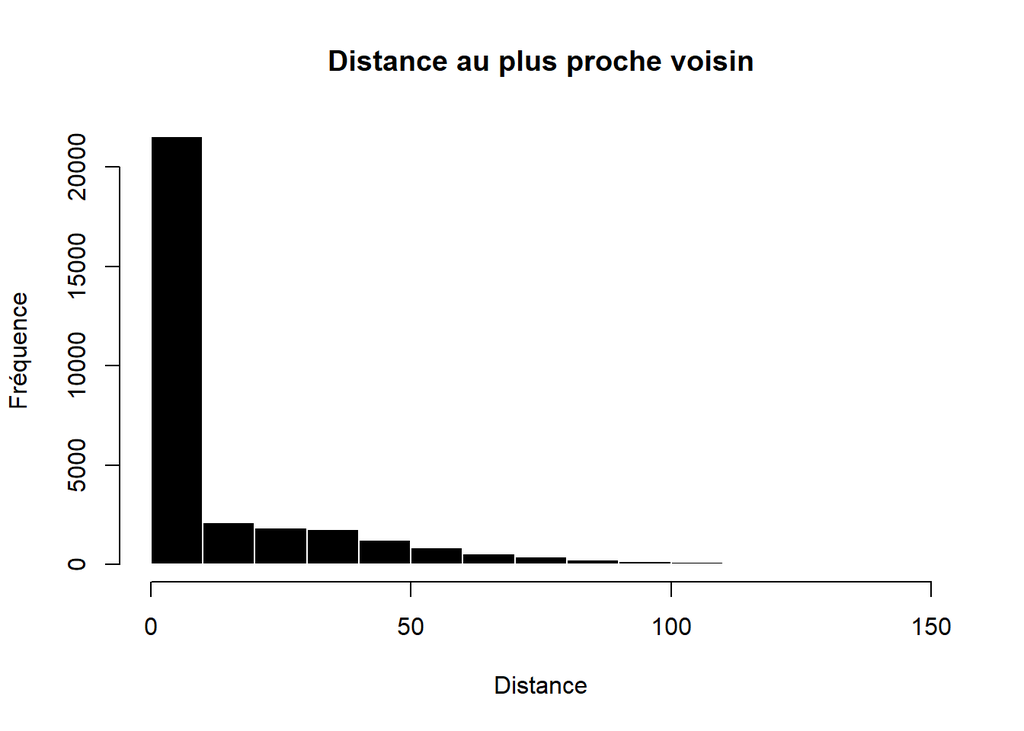

```r
hist(unlist(distPPV), nclass = 200,
     main = "Distance au plus proche voisin",
     col = "black", border = "white", xlab = "Distance", ylab = "Fréquence", xlim = c(0,150))
```

```r
#calcul du test de Moran
moran.test(MutationsRM$prixm2, listw = nb2listw(PPV))
```

```
##
##  Moran I test under randomisation
##
## data:  MutationsRM$prixm2
## weights: nb2listw(PPV)
##
## Moran I statistic standard deviate = 80.479, p-value < 2.2e-16
## alternative hypothesis: greater
## sample estimates:
## Moran I statistic       Expectation          Variance
##      5.345203e-01     -3.152486e-05      4.411811e-05
```

#### 1.6.3.2 Carte lissée des prix de l’immobilier au m² calculés directement à partir des mutations immobilières sur l’ensemble de Rennes Métropole

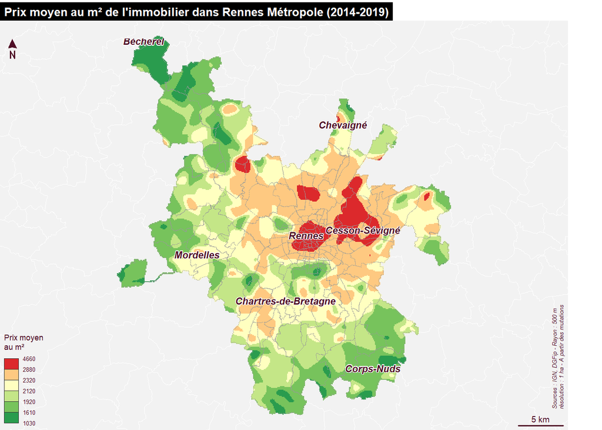

```r
# pour définir comme emprise pour le lissage, l'étendue de Rennes métropole avec une zone tampon de 1 km (2 sigma) autour afin d'englober les mutations limitrophes et réduire l'effet de bord
zone_tampon <- st_union(IRISRM) |> st_buffer(1000)   # 2 sigma
EmpriseRM.ZT <- vect(zone_tampon)

# pour ne retenir que les mutations situées dans le rectangle englobant et les convertir en SpatVector (filtre rapide)
pts <- MutationsBZH %>%
  st_filter(st_as_sfc(st_bbox(zone_tampon))) %>%
  vect()

# raster support (100 m, soit 1 ha par pixel)
r0 <- rast(ext(EmpriseRM.ZT),
           resolution = 100,
           crs = crs(EmpriseRM.ZT))

# pour calculer par pixel la somme des prix au m² et le nombre de mutations (NA remplacés par 0)
somme <- rasterize(pts, r0, field = "prixm2", fun = "sum")
nb    <- rasterize(pts, r0, fun = "count")
somme <- subst(somme, NA, 0)
nb    <- subst(nb, NA, 0)

# pour créer le noyau gaussien (rayon de lissage, sigma : 500 m)
matrice_poids <- focalMat(r0, d = 500, type = "Gauss")

# pour calculer le numérateur et le dénominateur du lissage
num <- focal(somme,
             w = matrice_poids,
             fun = "sum",
             fillvalue = 0)

den <- focal(nb,
             w = matrice_poids,
             fun = "sum",
             fillvalue = 0)

# pour obtenir la surface lissée (moyenne pondérée)
cartelissee.raster <- num / den
names(cartelissee.raster) <- "Prixm2Lisse"

# pour découper la surface lissée sur l'emprise de Rennes Métropole
cartelissee.raster <- mask(cartelissee.raster, vect(IRISRM))

# Paramétrage des marges de la fenêtre pour maximiser l'emprise de la carte
op <- par(mar = c(0, 0, 1.2, 2))

# pour afficher la surface lissée et définir l'habillage de la carte
# Calcul des seuils
bks <- unique(mf_get_breaks(values(cartelissee.raster), breaks = "q6"))

# Création d'une palette de couleurs (double gradation harmonique)
cols <- c("#2a9c4e", "#77c35c", "#c4e687", "#ffffc0", "#fec981", "#dc292c")

# Affichage des communes de RM et alentours en arrière-plan et centrage de la carte sur Rennes Métropole
plot(st_geometry(Communes),
     lwd = 0.1,
     col = "grey95",
     border = "white",
     bg = "#B5D0D0",
     xlim = c(st_bbox(IRISRM)[1], st_bbox(IRISRM)[3]),
     ylim = c(st_bbox(IRISRM)[2], st_bbox(IRISRM)[4]))

# Affichage de la carte lissée et du contour des IRIS
plot(cartelissee.raster,
     breaks = bks,
     col = cols,
     add = TRUE, legend = FALSE)
plot(IRISRM$geometry,
     border = "grey60",
     lwd = 0.05,
     lty = 3,
     add = TRUE)

mf_legend(type = "choro",
          pos = "bottomleft",
          title = "Prix moyen \nau m²",
          val = bks,
          no_data = FALSE,
          val_rnd = -1,
          pal = cols,
          size = 0.7)

# Habillage de la carte
mf_title("Prix moyen au m² de l'immobilier dans Rennes Métropole (2014-2019)", cex = 0.8, tab = TRUE, fg = "white", bg = "black", line = 1, pos = "left")

mf_arrow(adj = c(1,-3))
mf_scale()

mf_credits(txt = "         Sources : IGN, DGFip - Rayon : 500 m\n         résolution : 1 ha - A partir des mutations", cex = 0.4, pos = 'rightbottom')

# Ajouter les étiquettes des communes sélectionnées plus haut
mf_label(Selection_Communes_RM, var = "NOM_COM", halo = TRUE, bg = "white", r = 0.05, cex = 0.7, pos = 3, font = 4, offset = 0)
```

```r
par(op)
```

#### 1.6.3.3 Carte lissée des prix de l’immobilier au m² et du nombre de mutations, calculés directement à partir des mutations immobilières sur l’ensemble de Rennes Métropole

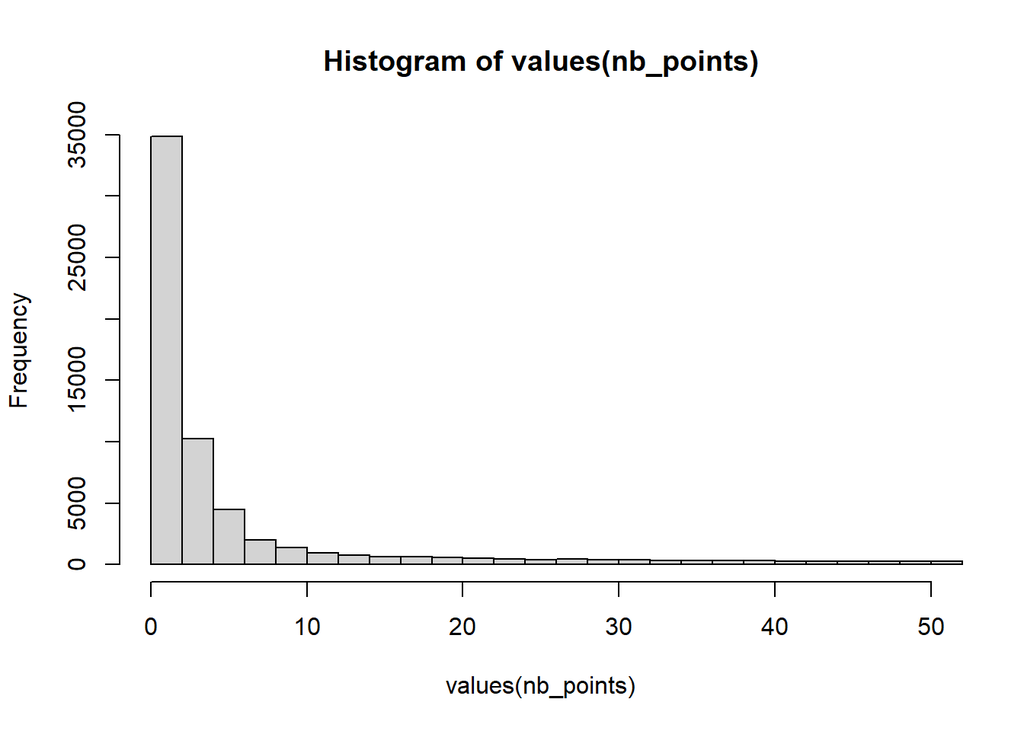

```r
# noyau circulaire (rayon 500 m) : matrice de 0/1, sans pondération
matrice_poids2 <- focalMat(r0, d = 500, type = "circle")
matrice_poids2[matrice_poids2 > 0] <- 1

# nombre de mutations par pixel (NA remplacés par 0)
nb <- subst(rasterize(pts, r0, fun = "count"), NA, 0)

# nombre de mutations dans la fenêtre circulaire de 500 m autour de chaque pixel
nb_fenetre <- focal(nb, w = matrice_poids2, fun = "sum", fillvalue = 0)

# découpage du raster correspondant au nombre de mutations, sur l'emprise de Rennes métropole
nb_points <- mask(nb_fenetre, vect(IRISRM))

# histogramme
hist(values(nb_points), breaks = 1000, xlim = c(0,50))
```

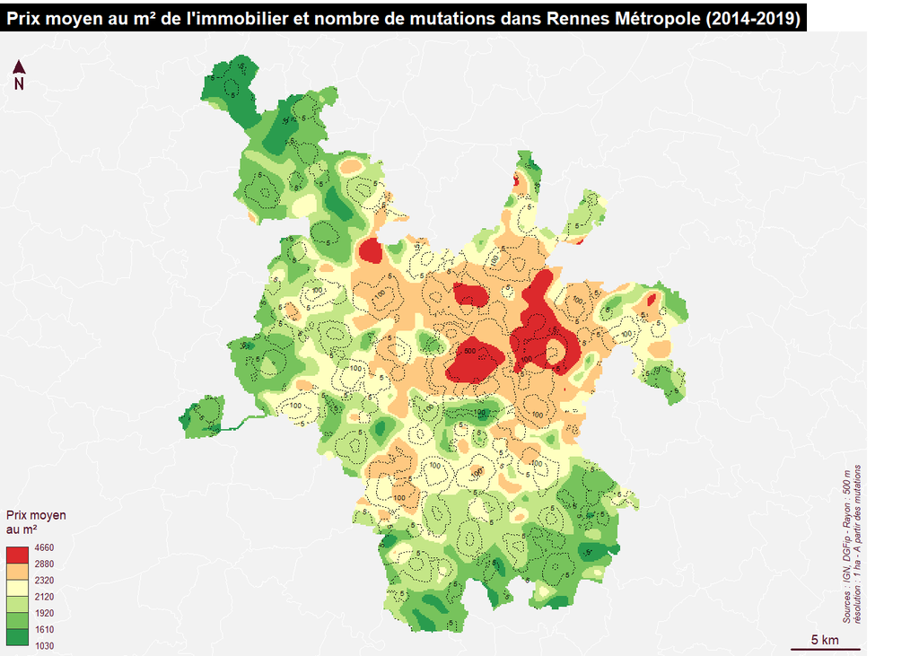

```r
# Paramétrage des marges de la fenêtre pour maximiser l'emprise de la carte
op <- par(mar = c(0, 0, 1.2, 2))

# pour afficher la surface lissée et définir l'habillage de la carte
# Calcul des seuils
bks <- unique(mf_get_breaks(values(cartelissee.raster), breaks = "q6"))

# Création d'une palette de couleurs (double gradation harmonique)
cols <- c("#2a9c4e", "#77c35c", "#c4e687", "#ffffc0", "#fec981", "#dc292c")

# Affichage des communes de RM et alentours en arrière-plan et centrage de la carte sur Rennes Métropole
plot(st_geometry(Communes),
     lwd = 0.1,
     col = "grey95",
     border = "white",
     bg = "#B5D0D0",
     xlim = c(st_bbox(IRISRM)[1], st_bbox(IRISRM)[3]),
     ylim = c(st_bbox(IRISRM)[2], st_bbox(IRISRM)[4]))

# Affichage de la carte lissée des prix au m²
plot(cartelissee.raster,
     breaks = bks,
     col = cols,
     add = TRUE, legend = FALSE)

niveaux <- c(5,100, 500)

contour(nb_points,
        lwd = 0.1,
        labcex = 0.3,
        lty = 3,
        levels = niveaux,
        add = TRUE)

mf_legend(type = "choro",
          pos = "bottomleft",
          title = "Prix moyen \nau m²",
          val = bks,
          no_data = FALSE,
          val_rnd = -1,
          pal = cols,
          size = 0.7)

# Habillage de la carte
mf_title("Prix moyen au m² de l'immobilier et nombre de mutations dans Rennes Métropole (2014-2019)", cex = 0.8, tab = TRUE, fg = "white", bg = "black", line = 1, pos = "left")

mf_arrow(adj = c(1,-3))
mf_scale()

mf_credits(txt = "         Sources : IGN, DGFip - Rayon : 500 m\n         résolution : 1 ha - A partir des mutations", cex = 0.4, pos = 'rightbottom')
```

```r
par(op)
```

## 1.7 Elaboration d’une typologie à partir d’indicateurs immobiliers et cartographie des sous-marchés associés (échelle métropolitaine)

### 1.7.1 Récupération du code Iris sur les mutations (jointure spatiale)

```r
MutationsIRIS <- MutationsRM %>% st_join(IRISRM["code_iris"])
MutationsIRIS <- st_drop_geometry(MutationsIRIS)
```

### 1.7.2 Création d’un tableau avec les variables par Iris à soumettre à la CAH

```r
IRISDVFClassif1 <- MutationsIRIS %>% group_by(code_iris) %>%
  summarise(Nbtransactions = n(),
            Prixmoyen = round(mean(prix)),
            Prixm2moyen = round(mean(prixm2)),
            Surfacemoyenne = round(mean(surface)),
            PropMaison = length(type[type == "Maison"]) / Nbtransactions * 100,
            PropAppart = length(type[type == "Appartement"]) / Nbtransactions * 100)

IRISDVFClassif <- data.frame(IRISDVFClassif1[, c("Nbtransactions", "Prixmoyen", "Prixm2moyen", "Surfacemoyenne", "PropMaison", "PropAppart")])
```

### 1.7.3 Centrage et réduction des variables

```r
IRISDVFClassifScale <- scale(IRISDVFClassif)
```

### 1.7.4 Mise en oeuvre de la CAH

```r
CAHIRIS <- agnes(IRISDVFClassifScale,
                     metric = "euclidean",
                     method = "ward")
```

### 1.7.5 Graphiques des gains d’inertie inter-classe

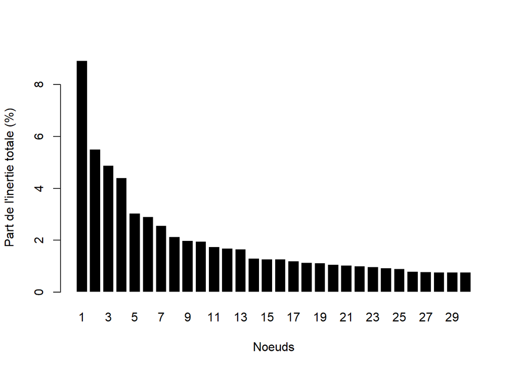

```r
sortedHeight<- sort(CAHIRIS$height, decreasing = TRUE)
relHeight<-sortedHeight / sum(sortedHeight) * 100

barplot(relHeight[1:30], names.arg = seq(1, 30, 1), col = "black", border = "white", xlab = "Noeuds", ylab = "Part de l'inertie totale (%)")
```

### 1.7.6 Arbre de classification hiérarchique

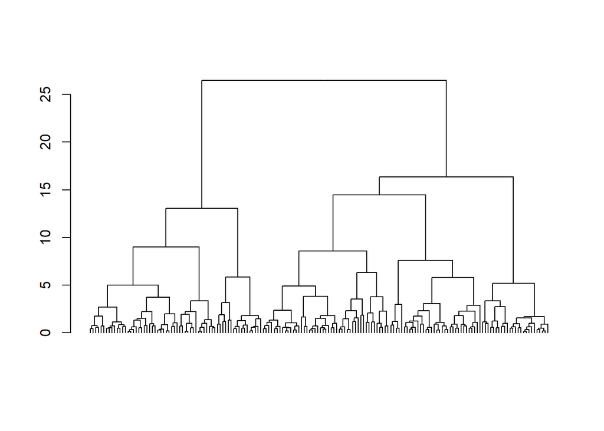

```r
dendroCSP <- as.dendrogram(CAHIRIS)
plot(dendroCSP, leaflab = "none")
```

### 1.7.7 Partition (en n classes)

```r
clusIRIS <- cutree(CAHIRIS, k = 5)
IRISCluster <- IRISDVFClassif1
IRISCluster$CLUSIMMO <- factor(clusIRIS,
                                   levels = 1:5,
                                   labels = paste("Classe", 1:5))
```

### 1.7.8 Création d’un tableau avec les caractéristiques des groupes

```r
RecapCAHIRIS <- IRISCluster %>%
  group_by(CLUSIMMO) %>%
  dplyr::summarise(
    NbIris     = n(),
    NbTransac  = sum(Nbtransactions),
    Prixmoyen  = round(mean(Prixmoyen)),
    Prixm2     = round(mean(Prixm2moyen)),
    Surface    = round(mean(Surfacemoyenne)),
    PropMaison = mean(PropMaison),
    PropAppart = mean(PropAppart)
  )

print(RecapCAHIRIS)
```

```
## # A tibble: 5 × 8
##   CLUSIMMO NbIris NbTransac Prixmoyen Prixm2 Surface PropMaison PropAppart
##   <fct>     <int>     <int>     <dbl>  <dbl>   <dbl>      <dbl>      <dbl>
## 1 Classe 1     47      9352    190964   2068      94      70.9       29.1
## 2 Classe 2     17      1409    286322   2393     121      91.9        8.12
## 3 Classe 3     47      7542    221025   2817      78      39.2       60.8
## 4 Classe 4     34     10284    163057   2882      58       7.98      92.0
## 5 Classe 5     25      3135    126790   1782      72       8.32      91.7
```

### 1.7.9 Graphique des écarts à la moyenne

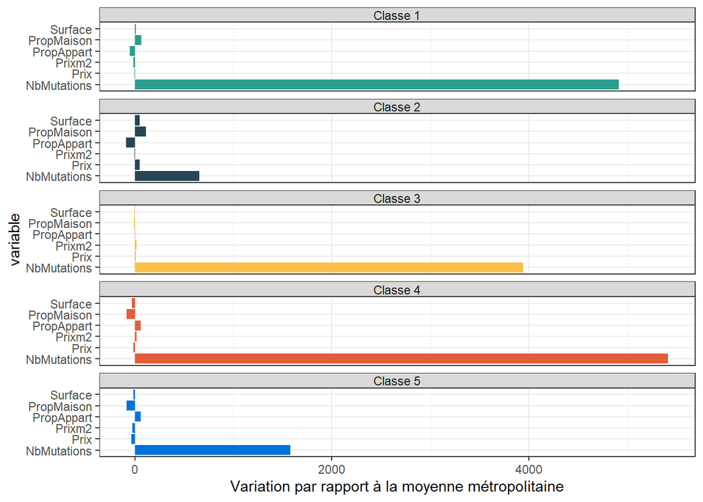

```r
SyntheseCAHIRIS <- RecapCAHIRIS %>%
  mutate(
    nbtransacmoy = mean(IRISDVFClassif$Nbtransactions),
    surfacemoy = mean(IRISDVFClassif$Surfacemoyenne),
    prixmoy = mean(IRISDVFClassif$Prixmoyen),
    prixm2moyen = mean(IRISDVFClassif$Prixm2moyen),
    propmaisonmoyen = mean(IRISDVFClassif$PropMaison),
    propappartmoyen = mean(IRISDVFClassif$PropAppart),
    NbMutations = (NbTransac - nbtransacmoy) / nbtransacmoy * 100,
    Prix = (Prixmoyen - prixmoy) / prixmoy * 100,
    Prixm2 = (Prixm2 - prixm2moyen) / prixm2moyen * 100,
    Surface = (Surface - surfacemoy) / surfacemoy * 100,
    PropMaison = (PropMaison - propmaisonmoyen) / propmaisonmoyen * 100,
    PropAppart = (PropAppart - propappartmoyen) / propappartmoyen * 100
  )

# pour créer un nouveau tableau avec une sélection de colonnes à faire apparaître sur le graphique
SyntheseCAHIRIS <- data.frame(SyntheseCAHIRIS[, c("CLUSIMMO", "NbMutations", "Surface", "Prix", "Prixm2", "PropMaison", "PropAppart")])

gather <- SyntheseCAHIRIS %>% gather(key = variable, value = "value", NbMutations:PropAppart)

ggplot(gather, aes(x = variable, y = value, fill = CLUSIMMO)) +
  geom_bar(stat = "identity") +
  coord_flip() +
  scale_fill_manual(values = c("#2A9D8F", "#264653", "#fcbf49", "#e45c3a", "#0074D9")) +
  ylab("Variation par rapport à la moyenne métropolitaine") +
  theme_bw() +
  theme(
    legend.position = "none",
    strip.text = element_text(margin = margin(t = 1, b = 1)),
    strip.background = element_rect()
  ) +
  facet_wrap(~CLUSIMMO, ncol = 1)
```

### 1.7.10 Carte de la typologie montrant les sous-marchés immobiliers métropolitains

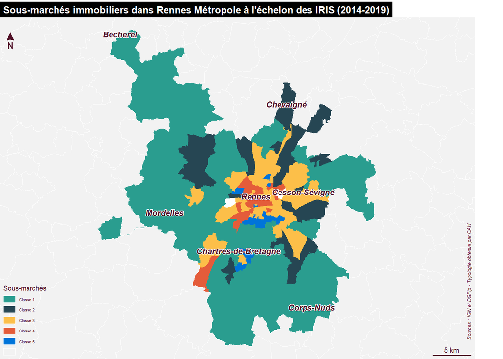

```r
# pour joindre le résultat de la typologie dans la couche des IRIS
IRISDVFCAH <- left_join(IRISRM, IRISCluster, by = "code_iris")

# Paramétrage des marges de la fenêtre pour maximiser l'emprise de la carte
op <- par(mar = c(0, 0, 1.2, 2))

# Création d'une palette de couleurs
cols <- c("#2A9D8F","#264653","#fcbf49","#e45c3a","#0074D9")

# Trier les valeurs
IRISDVFCAH <- IRISDVFCAH[order(IRISDVFCAH$CLUSIMMO, decreasing = FALSE),]

# Affichage des communes de RM et alentours en arrière-plan et centrage de la carte sur Rennes Métropole
plot(st_geometry(Communes), lwd = 0.1, col = "grey95", border = "white", bg = "#B5D0D0", xlim = c(st_bbox(IRISRM)[1], st_bbox(IRISRM)[3]), ylim = c(st_bbox(IRISRM)[2], st_bbox(IRISRM)[4]))

mf_map(
  type = 'typo',
  x = IRISDVFCAH,
  var = "CLUSIMMO",
  pal = cols,
  border = NA,
  leg_pos = NA,
  add = TRUE
  )

mf_legend(
  type = 'typo',
  pos = "bottomleft",
  val = unique(IRISDVFCAH$CLUSIMMO),
  pal = cols,
  title = "Sous-marchés",
  val_cex = 0.35,
  size = 0.7,
  box_cex = c(1, 0.75),
  box_border = "white"
)

# Habillage de la carte
mf_title("Sous-marchés immobiliers dans Rennes Métropole à l'échelon des IRIS (2014-2019)", cex = 0.8, tab = TRUE, fg = "white", bg = "black", line = 1, pos = "left")

mf_arrow(adj = c(1,-3))
mf_scale()

mf_credits(txt = "          Sources : IGN et DGFip - Typologie obtenue par CAH", cex = 0.4, pos = 'rightbottom')

# Ajouter les étiquettes des communes sélectionnées plus haut
mf_label(Selection_Communes_RM, var = "NOM_COM", halo = TRUE, bg = "white", r = 0.05, cex = 0.7, pos = 3, font = 4, offset = 0)
```

```r
par(op)
```

### 1.7.11 Export des Iris contenant la typologie issue de la CAH au format geopackage (pour une utilisation dans un SIG par exemple)

```r
st_write(IRISDVFCAH, "Resultats/IRISDVFCAH.gpkg", append = FALSE)
```

```
## Deleting layer `IRISDVFCAH' using driver `GPKG'
## Writing layer `IRISDVFCAH' to data source
##   `Resultats/IRISDVFCAH.gpkg' using driver `GPKG'
## Writing 172 features with 24 fields and geometry type Polygon.
```

## 1.8 Lissage spatial des prix au m² des appartements entre 2014 et 2019 : zoom sur la commune de Rennes

### 1.8.1 Préparation du jeu de données

```r
# pour ne garder que la commmune de Rennes
CommuneRennes <- Communes %>% filter(NOM_COM == "Rennes")

# pour ne garder que les mutations correspondant à des appartements dans Rennes Métropole (dans un premier temps)
MutationsApptRM <- MutationsRM %>% filter(type == "Appartement")

# pour créer une liste d'années, dans l'ordre
MutationsApptRM <- MutationsApptRM[order(MutationsApptRM$annee, decreasing = FALSE), ]
ListAnnees <- unique(MutationsApptRM$annee)

# pour définir comme emprise pour le lissage, l'étendue de Rennes avec une zone tampon de 1 km autour afin d'englober les mutations limitrophes et réduire l'effet de bord
EmpriseRennes <- as.owin(st_buffer(CommuneRennes, 1000))

# Création d'une palette de couleurs
cols <- c("#fff7f3", "#fee1d3", "#fcbea5", "#fc9777", "#fb7050", "#f14432", "#d42020", "#ad1016", "#67000d", "#480000", "#300000")
```

### 1.8.2 Série de cartes lissées montrant l’évolution des prix au m² des appartements calculés directement à partir des mutations à Rennes

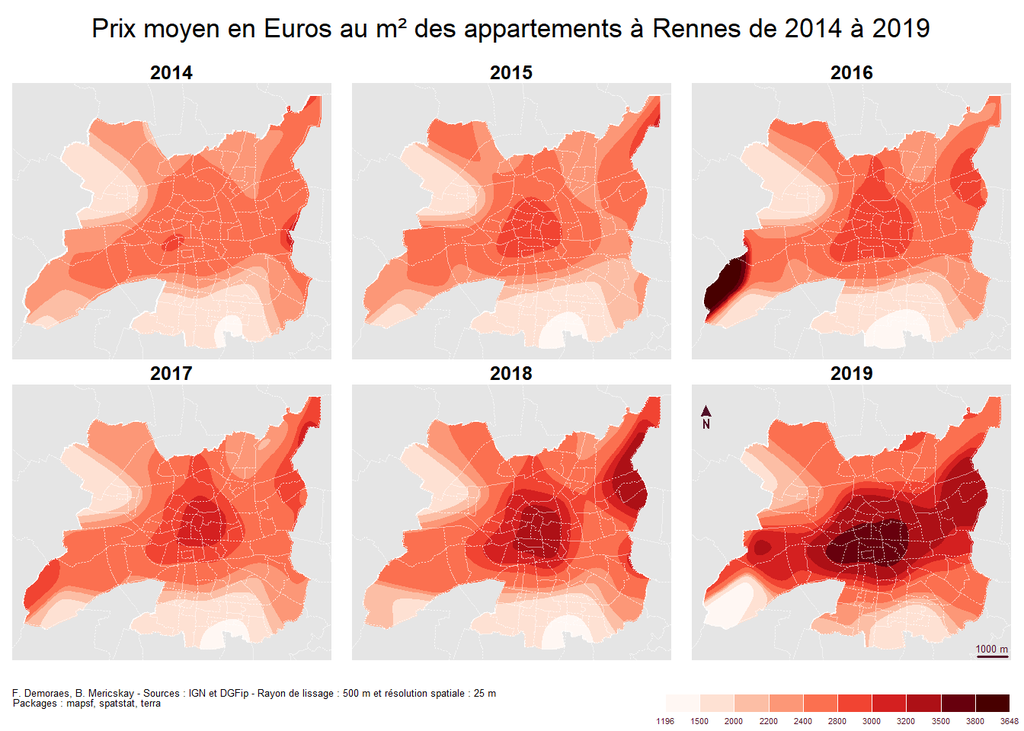

```r
# Paramétrage des marges pour insérer le titre général et les titres de chaque carte
par(oma = c(3.5,0,3,0)+0.1, mar = c(0, 0.5, 1.2, 0.5))

# pour découper la fenêtre en 2 lignes et 3 colonnes (6 années)
par(mfrow = c(2,3))

# boucle pour produire et cartographier une surface lissée par année
for (i in ListAnnees){

  # Recuperation des jeux de données par année
  fichier <- MutationsApptRM[which(MutationsApptRM$annee == i),]

  # pour récupérer les coordonnées des mutations
  pts <- st_coordinates(fichier)

  # pour creer un objet ppp (format spatstat) et y integrer dedans l'emprise et les valeurs a lisser (prix au m²)
  fichier.ppp <- ppp(pts[,1],
                     pts[,2],
                     window = EmpriseRennes,
                     marks = fichier$prixm2)

  # pour calculer la surface lissee (rayon lissage : 500 m et resolution spatiale de l'image : 25 m)
  cartelissee <- Smooth(fichier.ppp, sigma = 500, eps = 25)

  # Conversion de la surface lissée au format raster
  cartelissee.raster <- rast(cartelissee)
  crs(cartelissee.raster) <- st_crs(CommuneRennes)$srid

  # découpage sur emprise Rennes
  cartelissee.raster <- mask(cartelissee.raster, CommuneRennes)

  # Définition manuelle des seuils
  bks <- c(min(values(cartelissee.raster), na.rm = TRUE), 1500, 2000, 2200, 2400, 2800, 3000, 3200, 3500, 3800, max(values(cartelissee.raster), na.rm = TRUE))

  # Tracer la carte
  plot(st_geometry(CommuneRennes), border = "white", bg = "grey90")

  mf_raster(x = cartelissee.raster,
          var = "lyr.1",
          type = "interval",
          breaks = bks,
          pal = cols,
          leg_pos = NA,
          add = TRUE)

  plot(st_geometry(IRISRM), border = adjustcolor("white", alpha.f = 0.5), lty = 3, lwd = 0.01, add = TRUE)

  title(main = paste ("", i, sep = ""))

}

mf_scale(
  lwd = 1.5,
  cex = 0.6,
  pos = "bottomright",
  scale_units = "m"
)

mf_arrow(pos = "topleft", adj = c(1,-3))

# Pour afficher le titre principal et la source
mtext("Prix moyen en Euros au m² des appartements à Rennes de 2014 à 2019",
      cex = 1.1, side = 3,line = 1, adj = 0.5, outer = TRUE)
mtext("F. Demoraes, B. Mericskay - Sources : IGN et DGFip - Rayon de lissage : 500 m et résolution spatiale : 25 m",
      side = 1, line = 1, adj = 0.02, cex = 0.4, outer = TRUE)
mtext(" Packages : mapsf, spatstat, terra",
      side = 1, line = 1.5, adj = 0.01, cex = 0.4, outer = TRUE)

# Affichage de la légende (dans une nouvelle fenêtre graphique)
op <- par(fig = c(0, 1, 0, 1), oma = c(0, 0, 0, 0), mar = c(0, 0, 0, 0), new = TRUE)

plot.new()

mf_legend(
  type = 'choro',
  pos = "bottomright",
  val = bks,
  pal = cols,
  title = "",
  val_cex = 0.5,
  size = 0.7,
  no_data = FALSE,
  box_border = "white",
  box_cex = c(1, 3),
  horiz = TRUE
)
```

```r
par(op)
```